# FCR Met Data collation and Plots for EDI

2023-02-09

Master QAQC script in prep for publishing FCR Met station data to EDI this script using the qaqc_fcrmet function which automatically QAQCs the data. This script produces figures to look over the data to visually inspect it and make sure there are no major outlines. The final step is to write the final csv.

Use this file path in Carey Lab Reservoir GitHub Repo: “./Data/DataAlreadyUploadedToEDI/EDIProductionFiles/MakeEML_FCRMetData/2023/”

This step gets the right packages and sources the sources the QAQC script. Make sure you have the correct year for the script file

## Read in the QAQC File and Check it out

This section reads in the QAQC file and then you can look at the head, tail and structure. Make sure the last row is Dec. 31 23:59 of the publishing year. There should be 45 columns unless a new one has been added.

```r
# read in qaqc function output

fcrmetdata <- read_csv(output_file, col_types = cols(Note_BP_Average_kPa = col_character(), DateTime = col_datetime()))
fcrmetdata <- read_csv("FCR_Met_final_2015_2022.csv")
# subset file to only unpublished data
fcrmetdata <- fcrmetdata[fcrmetdata$DateTime<ymd_hms(current_time_end),]

# what does the beginning look like
head(fcrmetdata)
```

```
## # A tibble: 6 × 45
##   Reservoir  Site DateTime            Record CR3000Bat…¹ CR300…² PAR_u…³ PAR_T…⁴
##   <chr>     <dbl> <dttm>               <dbl>       <dbl>   <dbl>   <dbl>   <dbl>
## 1 FCR          50 2015-07-07 15:45:00      0        13.3    31.2    1365      NA
## 2 FCR          50 2015-07-07 15:50:00      1        13.2    31.2    1155      NA
## 3 FCR          50 2015-07-07 15:55:00      2        13.2    31.3    1200      NA
## 4 FCR          50 2015-07-07 16:00:00      3        13.2    31.4    1194      NA
## 5 FCR          50 2015-07-07 16:05:00      4        13      31.5    1158      NA
## 6 FCR          50 2015-07-07 16:10:00      5        13.2    31.6    1131      NA
## # … with 37 more variables: BP_Average_kPa <dbl>, AirTemp_C_Average <dbl>,
## #   RH_percent <dbl>, Rain_Total_mm <dbl>, WindSpeed_Average_m_s <dbl>,
## #   WindDir_degrees <dbl>, ShortwaveRadiationUp_Average_W_m2 <dbl>,
## #   ShortwaveRadiationDown_Average_W_m2 <dbl>,
## #   InfraredRadiationUp_Average_W_m2 <dbl>,
## #   InfraredRadiationDown_Average_W_m2 <dbl>, Albedo_Average_W_m2 <dbl>,
## #   Flag_PAR_umolm2s_Average <dbl>, Note_PAR_umolm2s_Average <chr>, …
```

```r
# Make sure it goes to Dec 31st 23:59 of the previous year or your ending period
tail(fcrmetdata)
```

```
## # A tibble: 6 × 45
##   Reservoir  Site DateTime            Record CR3000Bat…¹ CR300…² PAR_u…³ PAR_T…⁴
##   <chr>     <dbl> <dttm>               <dbl>       <dbl>   <dbl>   <dbl>   <dbl>
## 1 FCR          50 2022-12-31 23:54:00 243989        12.4    13.0   0.162 0.00973
## 2 FCR          50 2022-12-31 23:55:00 243990        12.4    13.0   0.141 0.00846
## 3 FCR          50 2022-12-31 23:56:00 243991        12.4    13.0   0.162 0.00973
## 4 FCR          50 2022-12-31 23:57:00 243992        12.4    13.0   0.134 0.00803
## 5 FCR          50 2022-12-31 23:58:00 243993        12.4    13.0   0.148 0.00888
## 6 FCR          50 2022-12-31 23:59:00 243994        12.4    13.0   0.134 0.00803
## # … with 37 more variables: BP_Average_kPa <dbl>, AirTemp_C_Average <dbl>,
## #   RH_percent <dbl>, Rain_Total_mm <dbl>, WindSpeed_Average_m_s <dbl>,
## #   WindDir_degrees <dbl>, ShortwaveRadiationUp_Average_W_m2 <dbl>,
## #   ShortwaveRadiationDown_Average_W_m2 <dbl>,
## #   InfraredRadiationUp_Average_W_m2 <dbl>,
## #   InfraredRadiationDown_Average_W_m2 <dbl>, Albedo_Average_W_m2 <dbl>,
## #   Flag_PAR_umolm2s_Average <dbl>, Note_PAR_umolm2s_Average <chr>, …
```

```r
# check out the structure
str(fcrmetdata)
```

```
## tibble [3,699,434 × 45] (S3: tbl_df/tbl/data.frame)
##  $ Reservoir                               : chr [1:3699434] "FCR" "FCR" "FCR" "FCR" ...
##  $ Site                                    : num [1:3699434] 50 50 50 50 50 50 50 50 50 50 ...
##  $ DateTime                                : POSIXct[1:3699434], format: "2015-07-07 15:45:00" "2015-07-07 15:50:00" ...
##  $ Record                                  : num [1:3699434] 0 1 2 3 4 5 6 7 8 9 ...
##  $ CR3000Battery_V                         : num [1:3699434] 13.3 13.2 13.2 13.2 13 ...
##  $ CR3000Panel_Temp_C                      : num [1:3699434] 31.1 31.2 31.3 31.4 31.5 ...
##  $ PAR_umolm2s_Average                     : num [1:3699434] 1365 1155 1200 1194 1158 ...
##  $ PAR_Total_mmol_m2                       : num [1:3699434] NA NA NA NA NA NA NA NA NA NA ...
##  $ BP_Average_kPa                          : num [1:3699434] 101 102 102 102 102 ...
##  $ AirTemp_C_Average                       : num [1:3699434] 28.5 28.3 28.4 28.3 28.3 ...
##  $ RH_percent                              : num [1:3699434] 58.6 63 62.2 62.3 59.5 ...
##  $ Rain_Total_mm                           : num [1:3699434] 0 0 0 0 0 0 0 0 0 0 ...
##  $ WindSpeed_Average_m_s                   : num [1:3699434] 1.9 1.63 1.11 1.77 1.38 ...
##  $ WindDir_degrees                         : num [1:3699434] 0.006 0.006 0.006 0.012 0.006 0.006 0.006 0.006 0.006 0.006 ...
```

[output cut: 31 more lines]

As a reminder here are the flag codes Flag values

0: no flag;

1: value removed due to maintenance and set to NA;

2: sample not collected;

3: negative values set to 0, percent greater than 100 and set to 100, or infinite values set to NA;

4: potentially questionable value and changed or set to NA, see note;

5: questionable value but left in the dataset.

## QAQC Plots

These are QAQC plots to see if there are any questionable values we missed.

## Temperature

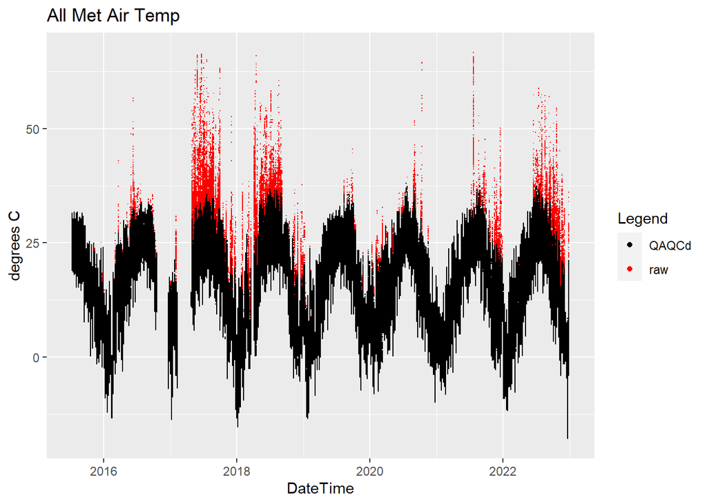

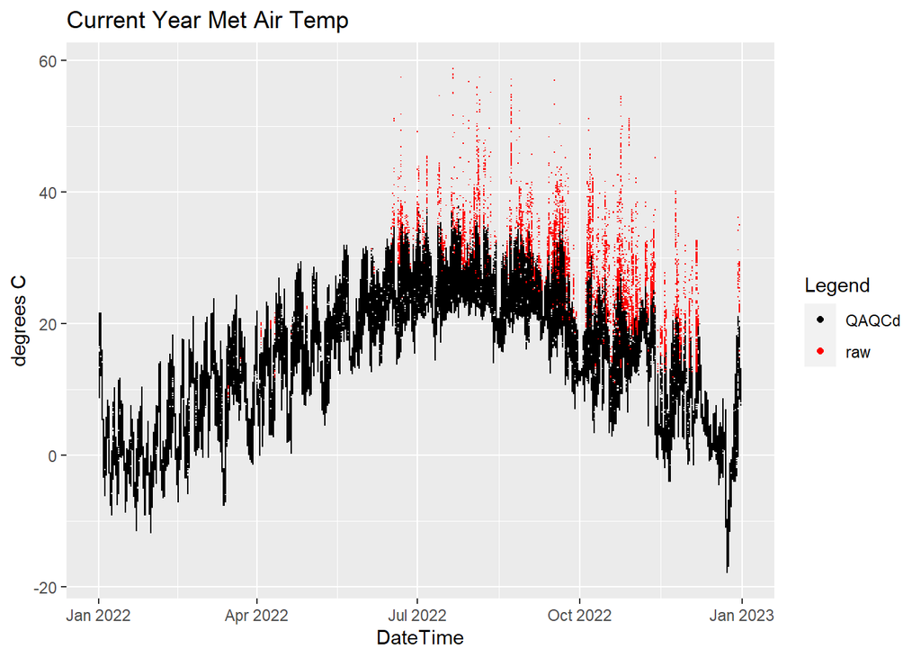

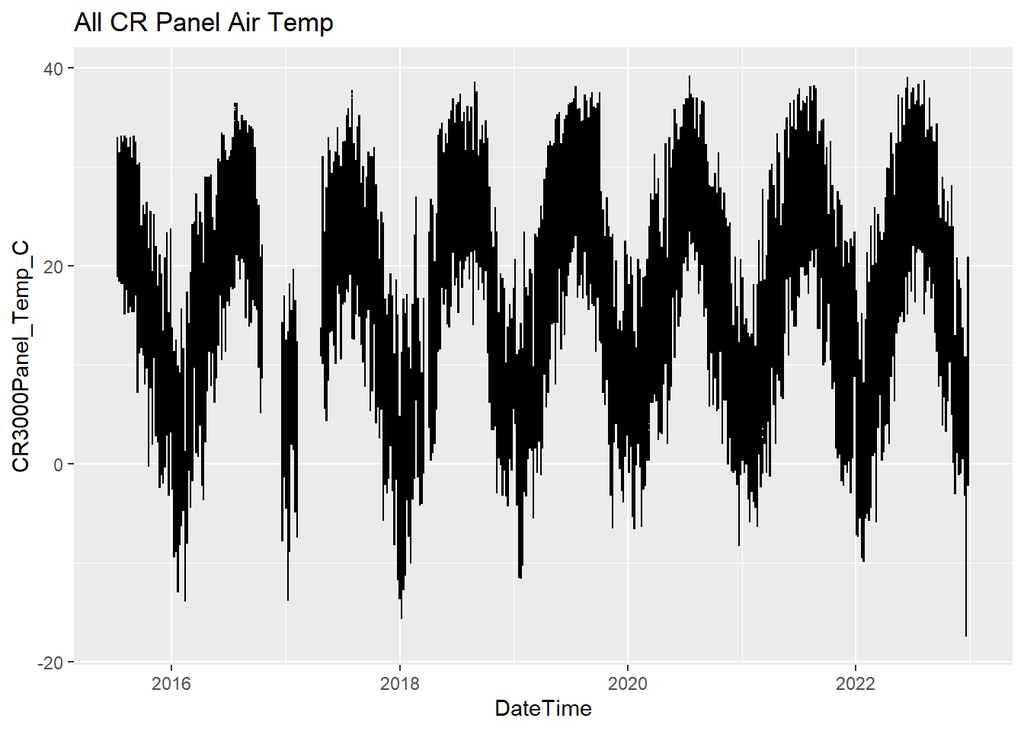

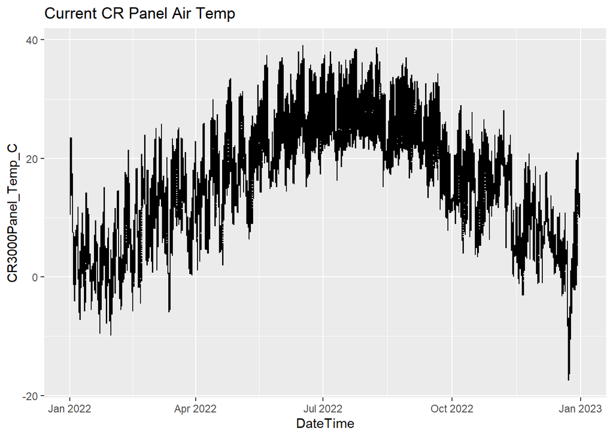

## PAR

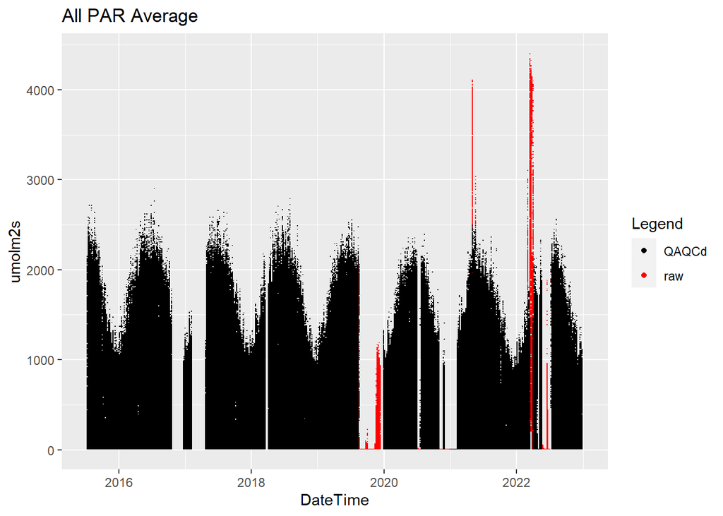

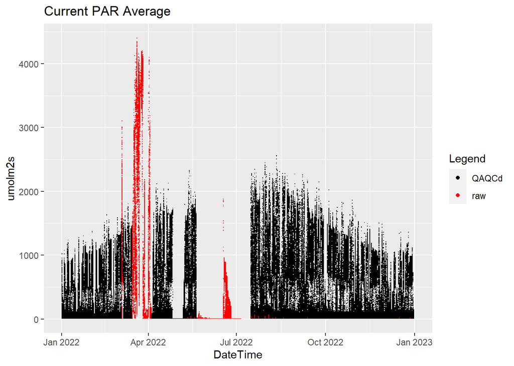

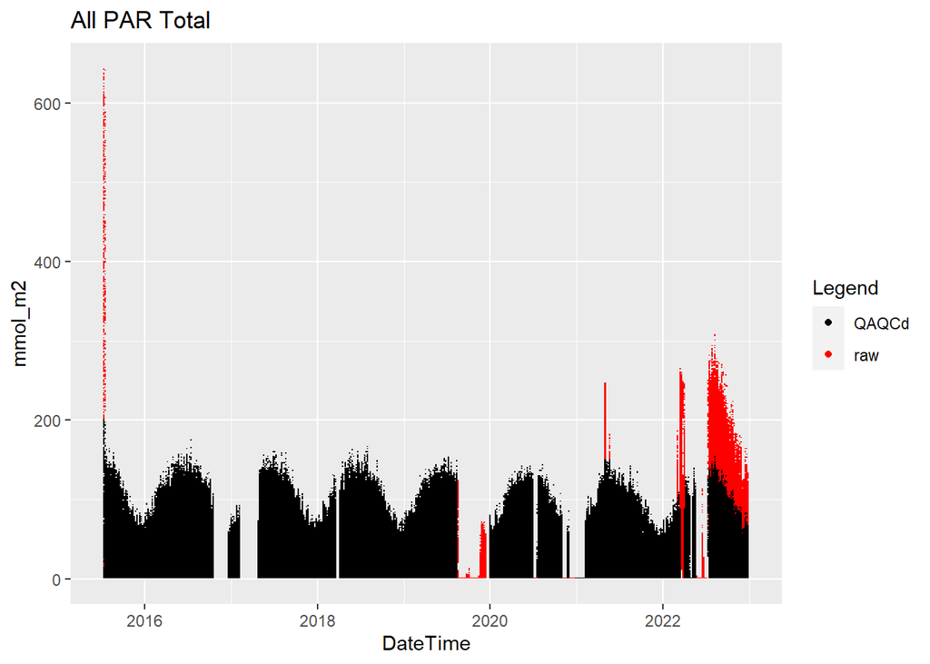

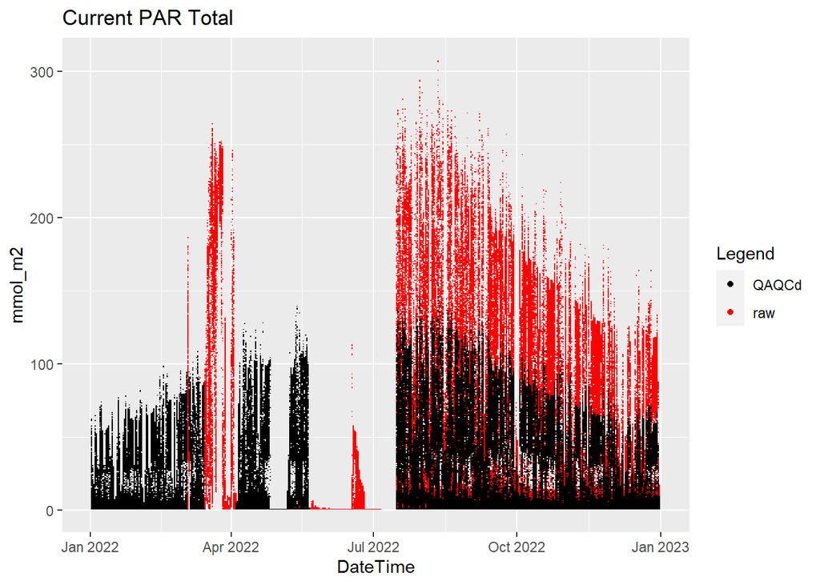

## Barometric Pressure

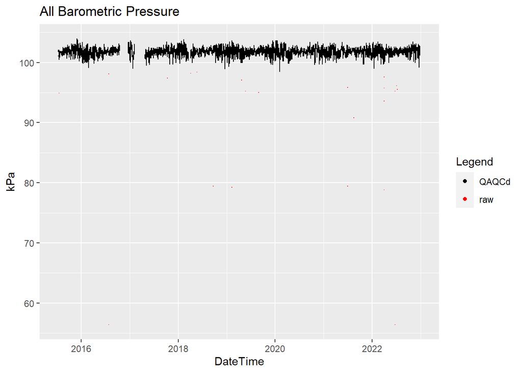

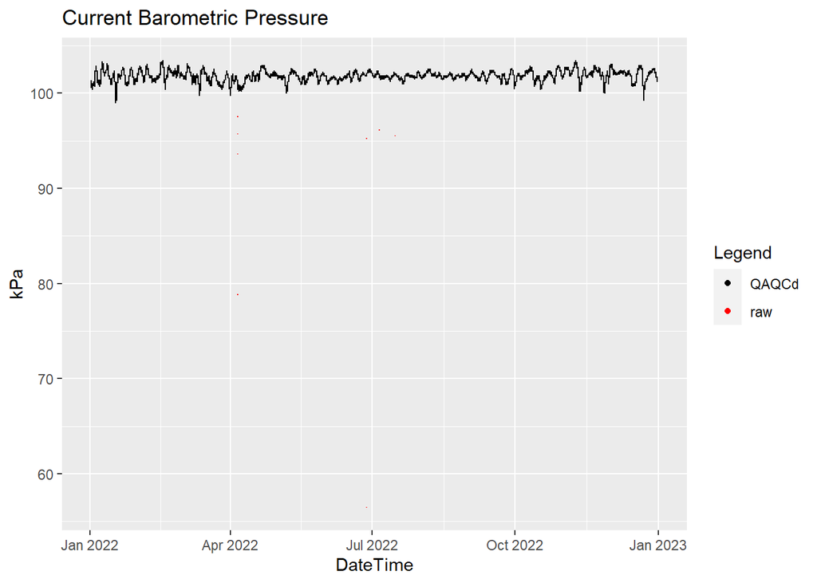

## Relative Humidity

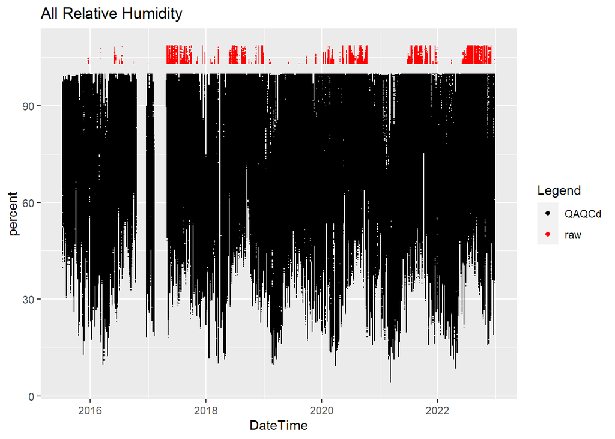

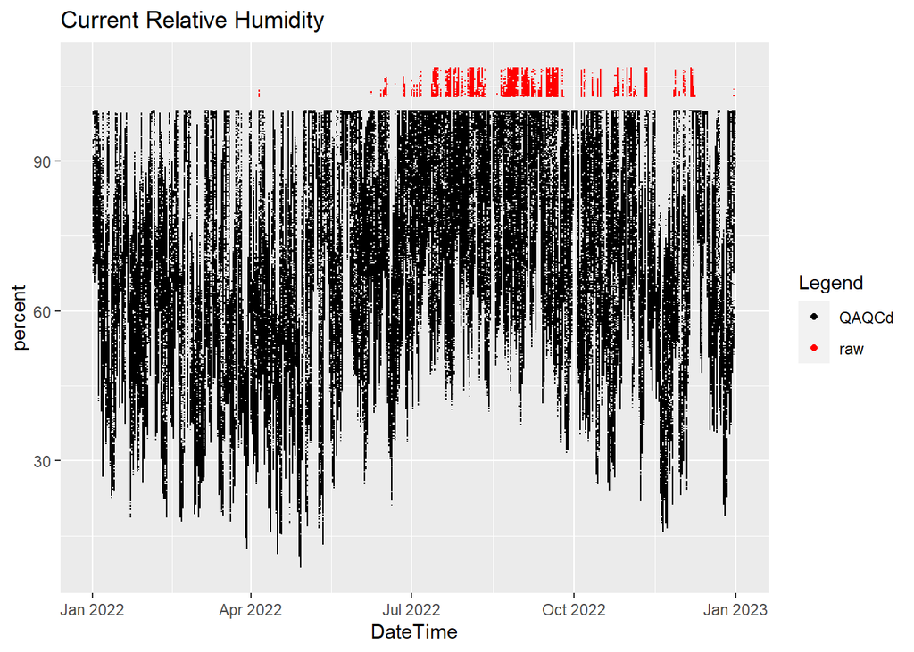

## Rain Total

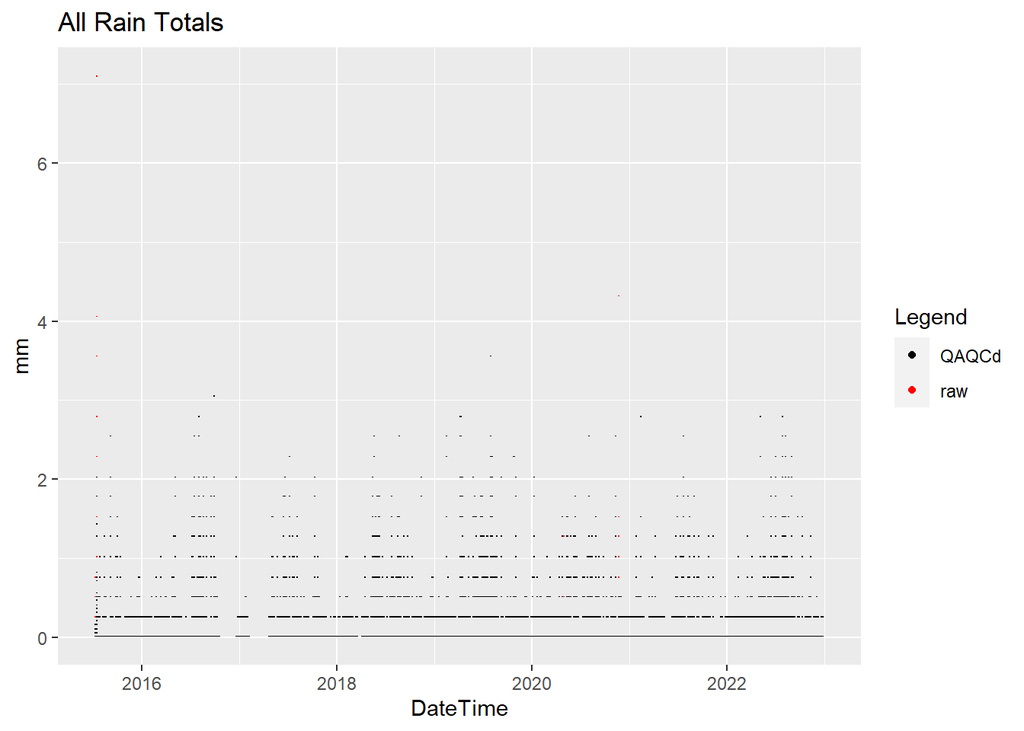

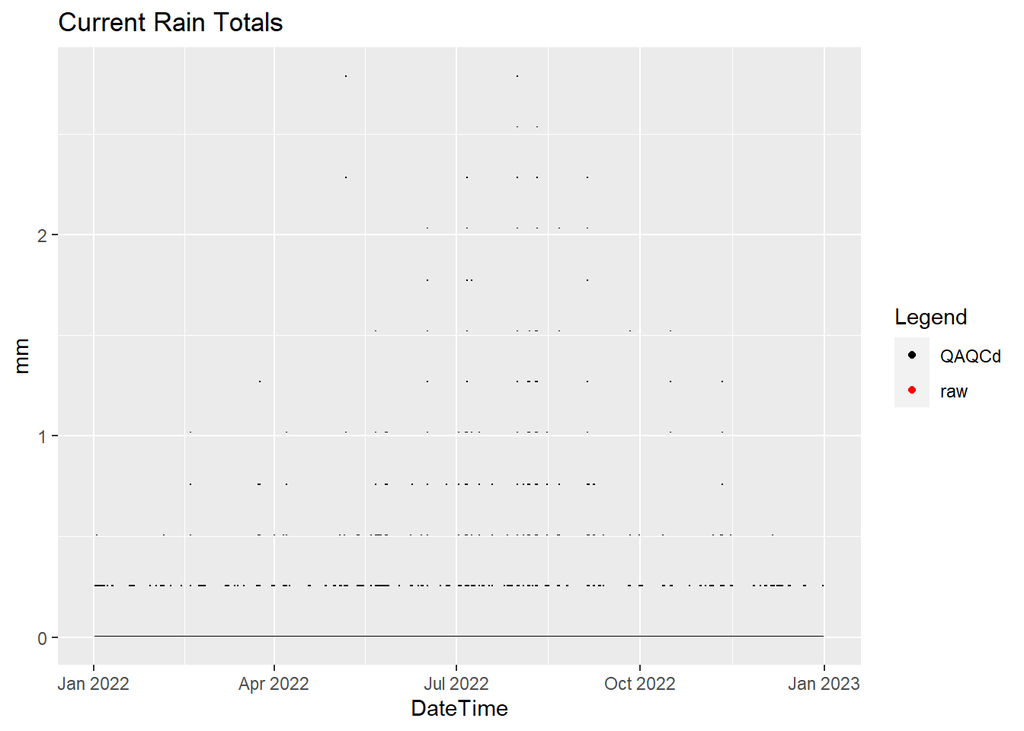

# Wind Speed and Direction

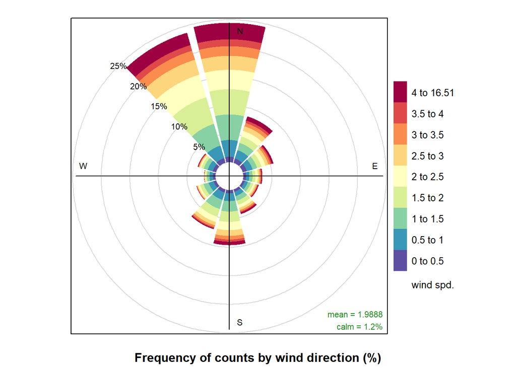

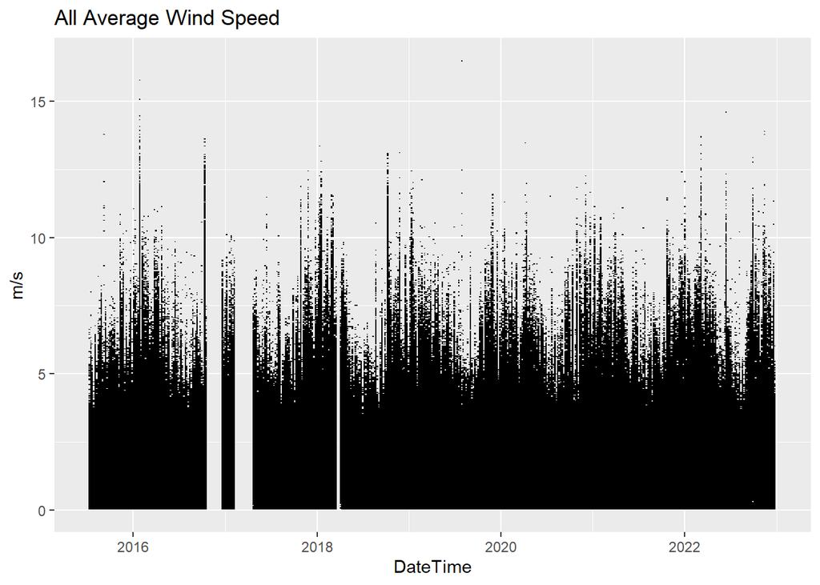

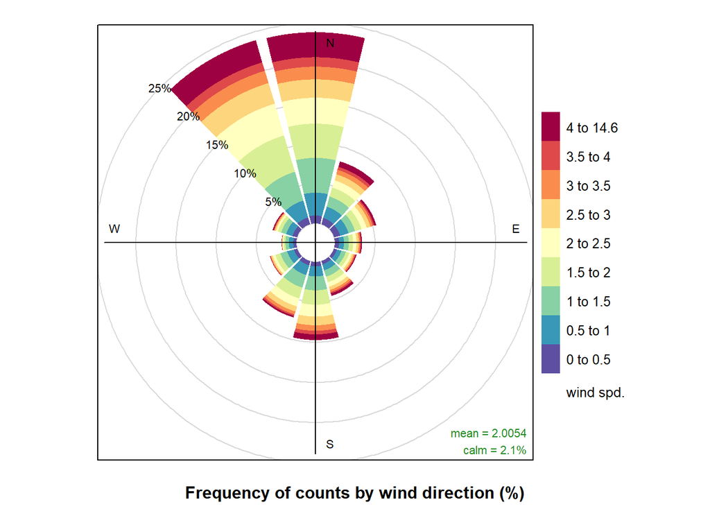

[figure not shown]

## Short Wave Radiation

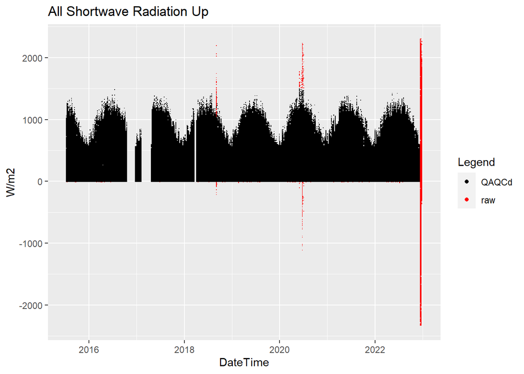

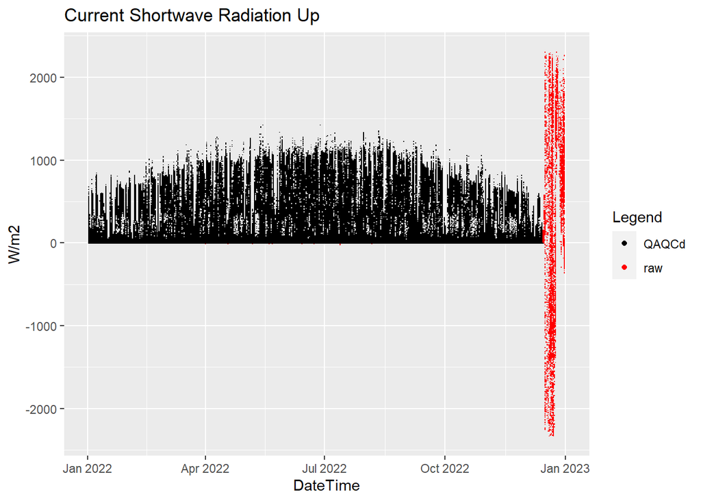

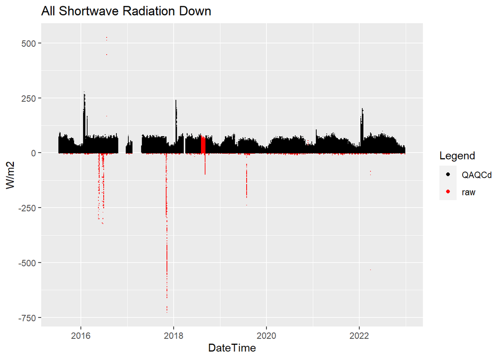

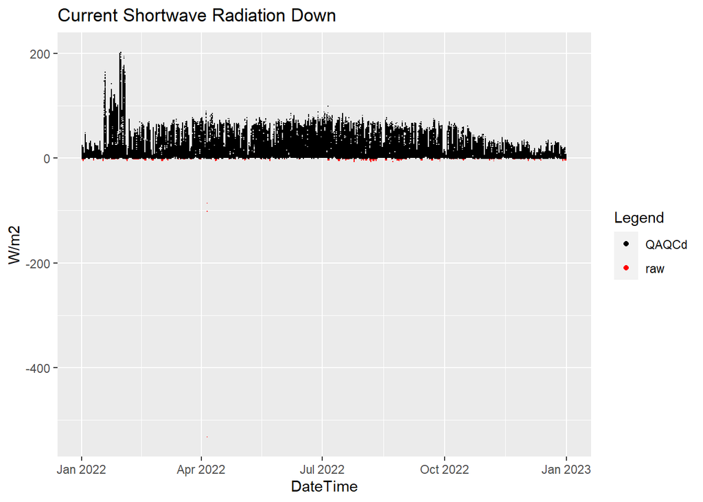

## Infrared Radiation

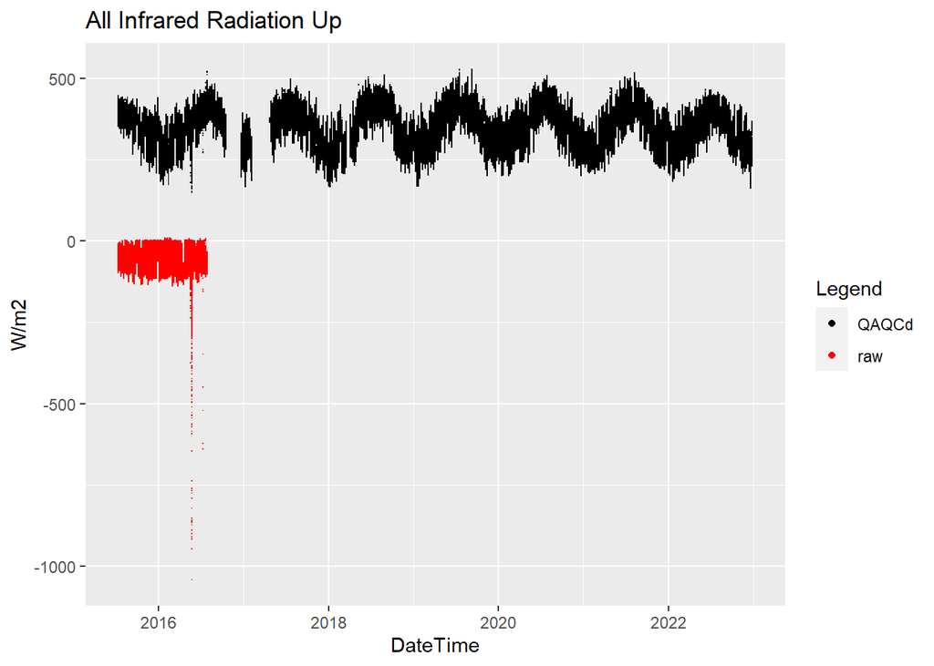

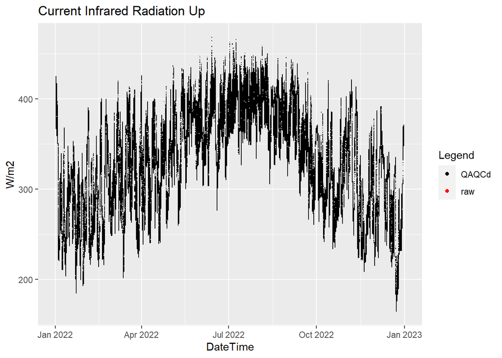

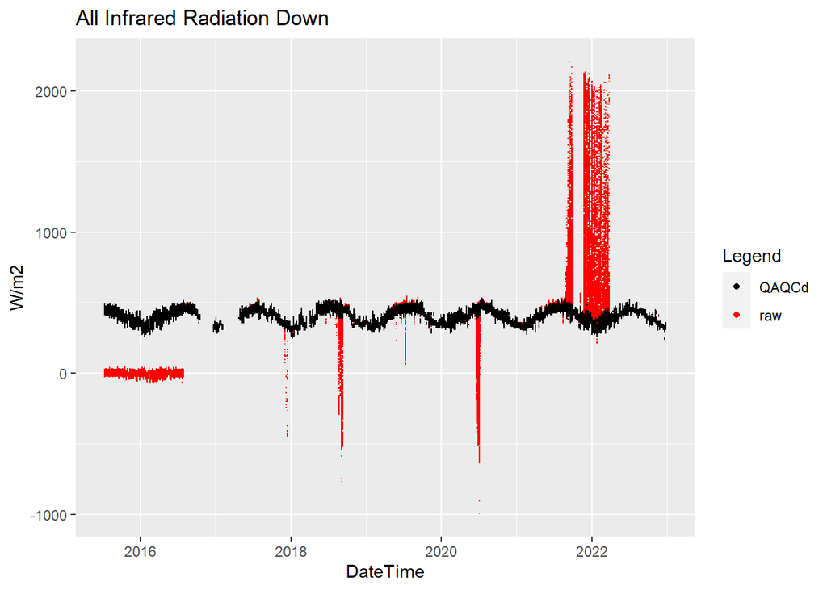

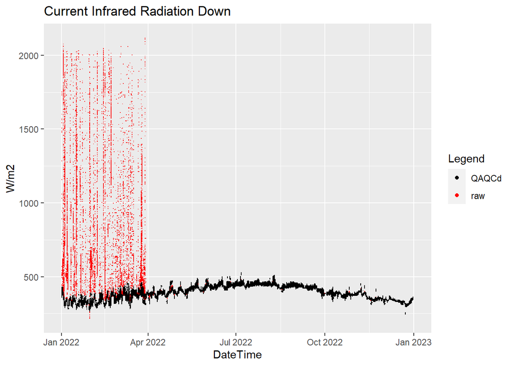

## Albedo

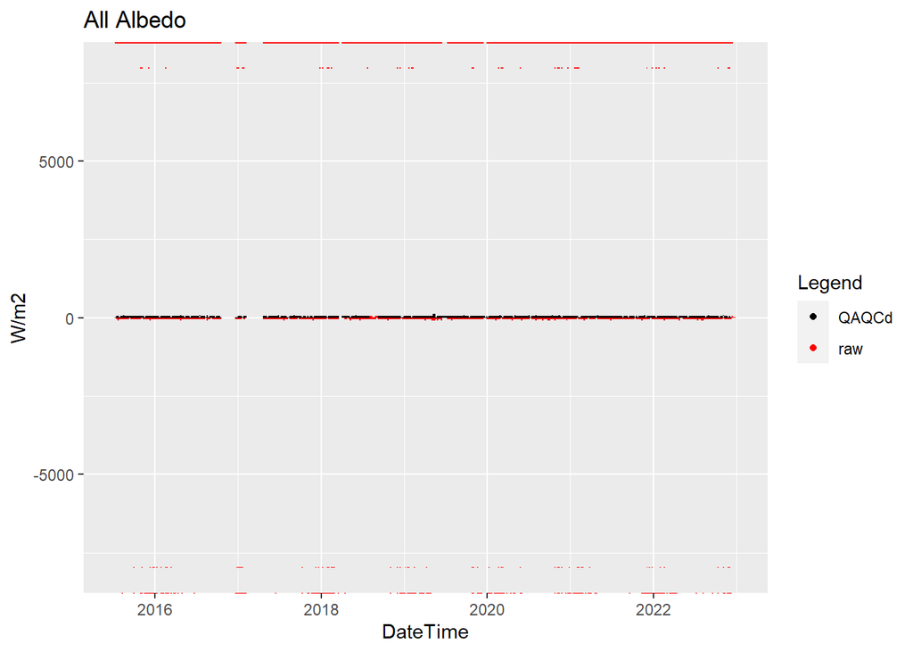

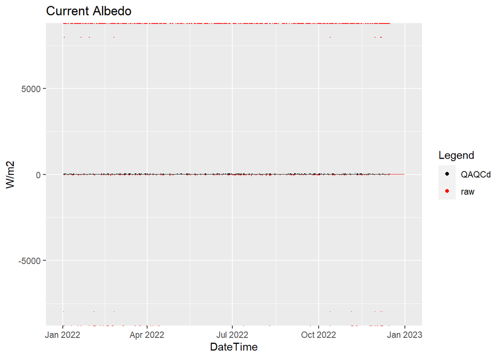